# Chapter 0 (2): R and RStudio

January 11, 2017

# Getting Started with R Console

Once you have opened RStudio you can begin to use R. R is an **interpreted language**, which means it answers your commands one by one in the console (the left half of the RStudio window). If you type

```r
3 + 4
```

and press *Enter*, the console responds right away

```
[1] 7
```

## TryIt!

Use R to add 615 to 247, then divided by 3, type `(615 + 247)/3` into the console then hitting Enter. Check your answer, is it

```
[1] 287.3333
```

# R Scripts

Instead of typing every commands in the console, and looking at your workflow “flows away”, we can use a **script**. Scripts are very useful in R because they allow us to save the commands that we’ve run. To open up a script, click *File* -> *New File* -> *R Script*. You should see that the console pane now moves down to reveal a new *Source pane*.

[interactive chart not shown]

You can type a line of code into the R script, then hit `Ctrl+Enter` in Windows or `Command+Enter` on Mac to run that line. Try typing 3+4 into your new R script then running that, look at how that line is copied to Console and run. It should look something like

[interactive chart not shown]

# Creating Variables

One of the nice things about R is that you can store a value (e.g. 4) or an object (e.g. a function description) into a **variable** in R. Later, you can use that variable to access to the information stored within it.

The following command assigns value `4` to a variable `my.var`

```r
my.var <- 4
```

## TryIt: Creating a Variable

To help you try out the code, I embed the Source and Console panes into this page. Complete the code in the editor as instructed.

> **Note**: Anything on a line that appears after `#` is considered a comment and will be ignored by the interpreter. Commenting in your code is a good programming practice to explain what you’re doing to the reader, and to the future you also.

## TryIt: Using Assigned Variables

The following template gives you the value of `a` is 5. Create another variable `b` with value 6, then add them together to find the total. Finally, create a new variable `c` taking the value of the above addition.

## An Error in R

A bright red error message should occur. Why is this?

1. R hates me
2. *R is case sensitive and I used a capital B*
3. R can only execute commands once

Note that the `B` has been capitalized

# MockJury Data

*Let’s return to RStudio.*

## Installing R Package

R is popular not only because it is open source (and free), but also because it is a *framework* where people can create their own functions and distribute them to others under the form of **packages**.

The data set called `MockJury` will be used as the example in Wednesday class. Let’s try it out today. The data set is built within the `heplots` package. To begin, we need to install the package (we need to do it only once!). Look at the bottom right pane. There you can choose *Packages* tab, and click *Install*. Type `heplots` when prompted and click `Install`. That easy!

To load `heplots` package, type `require(heplots)` into your R script on a new line and run that line of code. This loads all the code and data sets associated with the `heplots` package.

```r
require(heplots)
```

Let’s learn a little bit about the data set `MockJury` by loading R help page on the data by typing

```r
help(MockJury)
```

or

```r
`?`(MockJury)
```

The bottom right pane now changes into *Help* tab with the information about the data set. Read the data description and answer the following question

How many levels of attractiveness were recorded?

1. 1
2. 2
3. *3*

Beautiful, average, and unattractive.

Let’s load the data set to use.

```r
data(MockJury)
```

The data set is now named `MockJury`. You can now view it in the table form in Source pane by running (note the capital “V”)

```r
View(MockJury)
```

## Some R Commands on Data Set

Instead of viewing the entire data set, you can just show the first six rows using `head`. Change back into the script and run. The output is long and it may be cut into another block like below.

```r
head(MockJury)
```

```
##        Attr    Crime Years Serious exciting calm independent sincere warm
## 1 Beautiful Burglary    10       8        6    9           9       8    5
## 2 Beautiful Burglary     3       8        9    5           9       3    5
## 3 Beautiful Burglary     5       5        3    4           6       3    6
## 4 Beautiful Burglary     1       3        3    6           9       8    8
## 5 Beautiful Burglary     7       9        1    1           5       1    8
## 6 Beautiful Burglary     7       9        1    5           7       5    8
##   phyattr sociable kind intelligent strong sophisticated happy ownPA
## 1       9        9    9           6      9             9     5     9
## 2       9        9    4           9      5             5     5     7
## 3       7        4    2           4      5             4     5     5
## 4       9        9    9           9      9             9     9     9
## 5       8        9    4           7      9             9     8     7
## 6       8        9    5           8      9             9     9     9
```

Try

```r
tail(MockJury)
```

```
##        Attr   Crime Years Serious exciting calm independent sincere warm
## 109 Average Swindle     3       2        7    6           9       9    6
## 110 Average Swindle     2       1        8    8           8       8    8
## 111 Average Swindle     7       4        1    6           9       1    1
## 112 Average Swindle     6       3        5    3           5       2    4
## 113 Average Swindle    12       9        1    9           9       1    1
## 114 Average Swindle     8       8        1    9           1       5    1
##     phyattr sociable kind intelligent strong sophisticated happy ownPA
## 109       4        7    6           8      6             5     7     2
## 110       8        9    9           9      9             9     9     6
## 111       1        9    4           1      1             1     1     9
## 112       1        4    9           3      3             9     5     3
## 113       1        9    1           9      9             1     9     1
## 114       1        9    1           1      9             5     1     1
```

What does `tail(MockJury)` do?

1. Prints the first six rows of the dataset
2. Prints six randomly selected rows from the dataset
3. *Prints the last six rows of the dataset*
4. Summarizes the dataset

Look at the row numbers.

## Selecting Variables

Each column in the data set is named (these named columns are called variables). You can tell R to only print the “Years” variable using the dollar sign. The number in bracket gives you the position of the next value within a variable.

```r
MockJury$Years
```

```
##   [1] 10  3  5  1  7  7  3  7  2  3  5  1  1  1  2  2 10 10  3  4  7  1  4
##  [24]  3  2  8  8  1  1  5  7  1  5  2 12 10  1  6  2  5 12  6  3  8  4 10
##  [47] 10 15 15  3  3  3 11 12  2  1  1 12  5  5  4  3  6  4  9  8  3  2 10
##  [70]  1  1  3  1  3  5  8  1  1  2  2  3 15  4  6  2 10  3  2  3  5 10  2
##  [93]  2  2  3  1  1  1  2  2  1  1  2  3  4  5  3  3  3  2  7  6 12  8
```

## More R functions

We can easily compute numerical summaries of variables using R functions. Here, we compute the mean and standard deviation of the Years variable.

```r
mean(MockJury$Years)
```

```
## [1] 4.692982
```

```r
sd(MockJury$Years)
```

```
## [1] 3.633977
```

The `summary` function is very useful in R. For a quantitative variable, it will return the 5 number summary as well as the mean.

```r
summary(MockJury$Years)
```

```
##    Min. 1st Qu.  Median    Mean 3rd Qu.    Max.
##   1.000   2.000   3.000   4.693   7.000  15.000
```

## Plotting in R

We can use the `hist` and `boxplot` functions to make histograms and boxplots of the Years variable. The result will show in the bottom right pane, *Plots* tab.

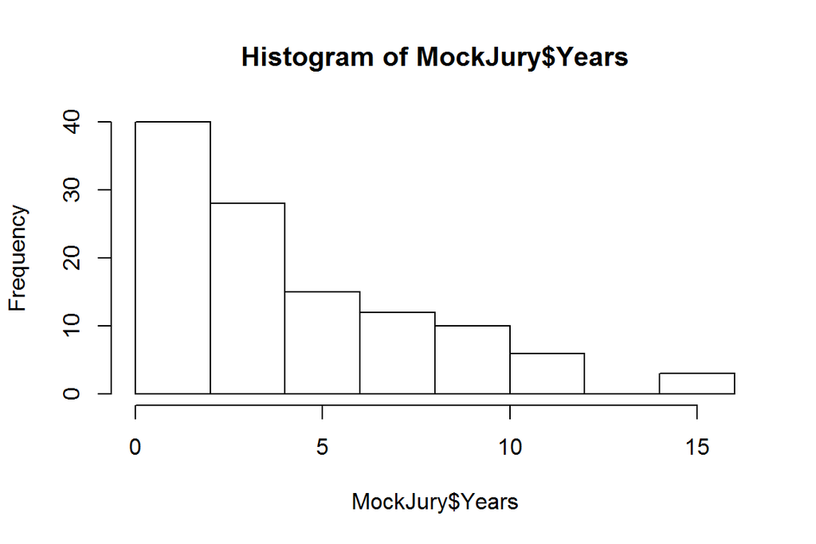

```r
hist(MockJury$Years)
```

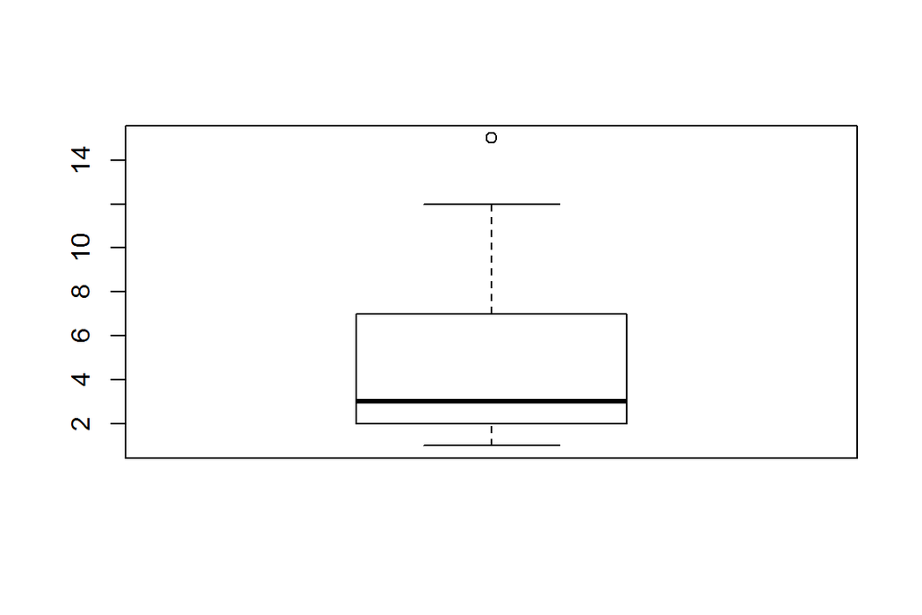

```r
boxplot(MockJury$Years)
```

# Want to Know More about R?

There is an intro R course at [Data Camp](https://www.datacamp.com/) with free registration. They cover most of basic R with good examples and an online edtior, which I embedded in this activity.